# STAT340 Lecture 08: Prediction continued: Multiple Regression

Portions of this taken from [ISLR notes](http://pages.stat.wisc.edu/~karlrohe/ht/03-linear_regression.pdf), [here](https://cran.r-project.org/web/packages/interactions/vignettes/interactions.html),

## Part 2: Multiple regression

*VERY SIMLIAR* to simple regression, just with more terms!

### Model formula

Natural way to extend simple linear prediction: add more predictors! For each observation $i$, consider the following model equation specification:

$$y_i = \beta_0 + \beta_1x_{i1} + \beta_2x_{i2}+...+\beta_px_{ip}+\epsilon_i$$

Where $\beta_k$ is the $k$-th coefficient and $x_{ik}$ is the $i$-th observation of the $k$-th predictor variable.

We can then again represent the loss function as

$$\text{RSS} = \sum_{i=1}^n (y_i - (\beta_0 + \beta_1x_{i1}+...+\beta_nx_{np}))^2$$

### Derivation of terms

This is now far outside the scope of this course. If you would like to see the standard definition of terms done elegantly with matrix algebra, click below. Otherwise, feel free to imagine this as being done magically with R!

> **Click to see derivation.**

> Let

> $$y=\begin{bmatrix}y_1\\y_2\\\vdots\\y_n\end{bmatrix}
> \quad
> X=\begin{bmatrix}
> 1&x_{11}&x_{12}&\cdots&x_{1p}\\
> 1&x_{21}&x_{22}&\cdots&x_{2p}\\
> \cdots&\cdots&\vdots&\ddots&\cdots\\
> 1&x_{n1}&x_{n2}&\cdots&x_{np}\\
> \end{bmatrix}
> \quad
> b=\begin{bmatrix}\beta_0\\\beta_1\\\beta_2\\\vdots\\\beta_n\end{bmatrix}
> \quad
> e=\begin{bmatrix}\epsilon_1\\\epsilon_2\\\vdots\\\epsilon_n\end{bmatrix}$$

> Then we can represent out model equation as

> $$y=Xb+e$$

> We can then represent our loss function as

> $$\begin{align*}
> e'e &= (y-Xb)'(y-Xb) \\
> &=y'y-b'X'y-y'Xb+b'X'Xb \\
> &=y'y-2b'X'y+b'X'Xb \\
> \end{align*}$$

> Where $e'$ is the transpose of $e$. Then, we can take a derivative of this with respect to $b$ (and using a matrix derivative identity [from here](https://en.wikipedia.org/wiki/Matrix_calculus#Scalar-by-vector_identities)) and set to 0 again to solve for $\hat{b}$

> $$\frac{\partial e'e}{\partial b}\bigg|_{b=\hat{b}}=-2X'y+2X'X\hat{b}=0$$

> We can rearrange to become

> $$(X'X)\hat{b}=X'y$$

> Solving for $\hat{b}$ gives us

> $$\hat{b} = (X'X)^{-1}X'y$$

> You can also easily derive the variance of the coefficients (where again we have used a matrix derivative identity to pull out the constant):

> $$\begin{align*}
> \operatorname{Var}(\hat{b})
> &=\operatorname{Var}((X'X)^{-1}X'y)\\
> &=\operatorname{Var}((X'X)^{-1}X'e)\\
> &=((X'X)^{-1}X')\cdot\operatorname{Var}(e)\cdot((X'X)^{-1}X')'\\
> &=\sigma^2((X'X)^{-1}X')\cdot I\cdot((X'X)^{-1}X')'\\
> &=\sigma^2((X'X)^{-1}X')((X'X)^{-1}X')'\\
> &=\sigma^2(X'X)^{-1}(X'X)(X'X)^{-1}\\
> &=\sigma^2(X'X)^{-1}
> \end{align*}$$

This process is exactly the same as 1 predictor regression, except we’re fitting a hyperplane through our data.

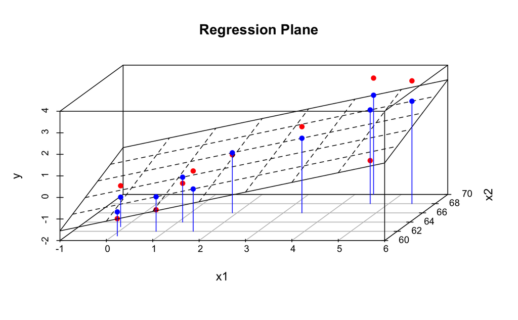

## Motivating example

The following motivating example comes from ISLR:

> Suppose that we are statistical consultants hired by a client to investigate the association between advertising and sales of a particular product. The Advertising data set consists of the sales of that product in 200 different markets, along with advertising budgets for the product in each of those markets for three different media: TV, radio, and newspaper.

> The data are displayed in the figure below (*all numbers are in thousands of units*). It is not possible for our client to directly increase sales of the product. On the other hand, they can control the advertising expenditure in each of the three media. Therefore, if we determine that there is an association between advertising and sales, then we can instruct our client to adjust advertising budgets, thereby indirectly increasing sales. In other words, our goal is to develop an accurate model that can be used to predict sales on the basis of the three media budgets.

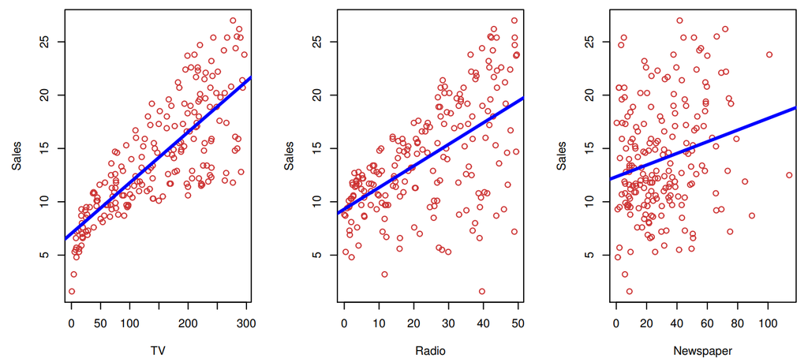

```r
library(tidyverse)
ad = read_csv("https://www.statlearning.com/s/Advertising.csv")[,-1]
head(ad)
```

```
## # A tibble: 6 x 4
##      TV radio newspaper sales
##   <dbl> <dbl>     <dbl> <dbl>
## 1 230.   37.8      69.2  22.1
## 2  44.5  39.3      45.1  10.4
## 3  17.2  45.9      69.3   9.3
## 4 152.   41.3      58.5  18.5
## 5 181.   10.8      58.4  12.9
## 6   8.7  48.9      75     7.2
```

We setup a model equation similar to that shown above, where

- X1 might be the TV
- X2 the radio budget
- X3 the newspaper budget

Here our model is

$$Y=\beta_{0}+\beta_{1} X_{1}+\beta_{2} X_{2}+\cdots+\beta_{p} X_{p}+\epsilon$$

- We interpret $\beta_{j}$ as the average effect on $Y$ of a one unit increase in $X_{j}$, holding all other predictors fixed. In the advertising example, the model becomes

$$\text { sales }=\beta_{0}+\beta_{1} \times \mathrm{TV}+\beta_{2} \times \text { radio }+\beta_{3} \times \text { newspaper }+\epsilon .$$

### New considerations

#### Interpretation

- The ideal scenario is when the predictors are uncorrelated, — a balanced design:
  - Each coefficient can be estimated and tested separately.
  - Interpretations such as “a unit change in $X_i$ is associated with a $\beta_i$ change in $Y$ , while all the other variables stay fixed”
- Correlations among predictors cause problems:
  - The variance of all coefficients tends to increase, sometimes dramatically
  - Interpretations become hazardous — when Xj changes, everything else changes.

This is an important thing to note, worth repeating:

> - a regression coefficient $\beta_i$ estimates the expected change in $Y$ per unit change in $X_i$ , with all other predictors held fixed, BUT predictors usually change together!
> - Example: $Y$ total amount of change in your pocket; X1 = # of coins; X2 = # of pennies, nickels and dimes. By itself, regression coefficient of Y on X2 will be > 0. But how about with X1 in model?

Given estimates $\hat{\beta}_{0}, \hat{\beta}_{1}, \ldots \hat{\beta}_{p}$, we can make predictions using the formula

$$\hat{y}=\hat{\beta}_{0}+\hat{\beta}_{1} x_{1}+\hat{\beta}_{2} x_{2}+\cdots+\hat{\beta}_{p} x_{p}$$

We estimate $\beta_{0}, \beta_{1}, \ldots, \beta_{p}$ as the values that minimize the sum of squared residuals.

$$\begin{aligned}
\mathrm{RSS} &=\sum_{i=1}^{n}\left(y_{i}-\hat{y}_{i}\right)^{2} \\
&=\sum_{i=1}^{n}\left(y_{i}-\hat{\beta}_{0}-\hat{\beta}_{1} x_{i 1}-\hat{\beta}_{2} x_{i 2}-\cdots-\hat{\beta}_{p} x_{i p}\right)^{2}
\end{aligned}$$

This is done using standard statistical software (again, see derivation above for details). The values $\hat{\beta}_{0}, \hat{\beta}_{1}, \ldots, \hat{\beta}_{p}$ that minimize $\mathrm{RSS}$ are the multiple least squares regression coefficient estimates.

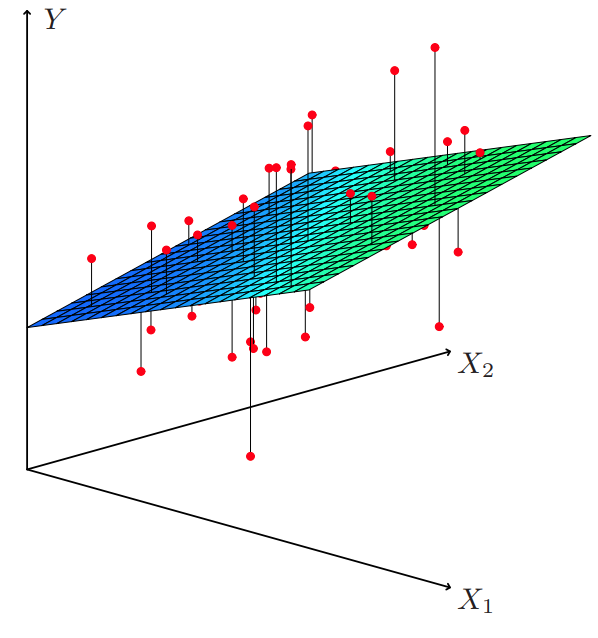

Results for advertising data ([see here](https://thomasleeper.com/Rcourse/Tutorials/formulae.html) for more discussion of R formula notation)

```r
lm.ad = lm(sales ~ TV + radio + newspaper, data = ad) #note: can also use:  sales ~ .
summary(lm.ad)
```

```
##
## Call:
## lm(formula = sales ~ TV + radio + newspaper, data = ad)
##
## Residuals:
##     Min      1Q  Median      3Q     Max
## -8.8277 -0.8908  0.2418  1.1893  2.8292
##
## Coefficients:
##              Estimate Std. Error t value Pr(>|t|)
## (Intercept)  2.938889   0.311908   9.422   <2e-16 ***
## TV           0.045765   0.001395  32.809   <2e-16 ***
## radio        0.188530   0.008611  21.893   <2e-16 ***
## newspaper   -0.001037   0.005871  -0.177     0.86
## ---
## Signif. codes:  0 '***' 0.001 '**' 0.01 '*' 0.05 '.' 0.1 ' ' 1
##
## Residual standard error: 1.686 on 196 degrees of freedom
## Multiple R-squared:  0.8972, Adjusted R-squared:  0.8956
## F-statistic: 570.3 on 3 and 196 DF,  p-value: < 2.2e-16
```

#### Categorical predictors

Suppose we want to use the Iris dataset and predict petal length from sepal length and width as well as species. Note species here is a categorical variable, this is not a problem!

By default R will automatically setup indicator variables for you for each level of each categorical variable. **NOTE** that one level (typically the first one by alphabetical order) will be chosen as the **reference level**. If an observation is the reference level, **no coefficient is added for that variable!**. If it’s a level **different from the reference level, then that level’s coefficient is added!**

Demo:

```r
lm.iris = lm(Petal.Length ~ Petal.Width + Sepal.Length + Sepal.Width + Species,data=iris)
summary(lm.iris)
```

```
##
## Call:
## lm(formula = Petal.Length ~ Petal.Width + Sepal.Length + Sepal.Width +
##     Species, data = iris)
##
## Residuals:
##      Min       1Q   Median       3Q      Max
## -0.78396 -0.15708  0.00193  0.14730  0.65418
##
## Coefficients:
##                   Estimate Std. Error t value Pr(>|t|)
## (Intercept)       -1.11099    0.26987  -4.117 6.45e-05 ***
## Petal.Width        0.60222    0.12144   4.959 1.97e-06 ***
## Sepal.Length       0.60801    0.05024  12.101  < 2e-16 ***
## Sepal.Width       -0.18052    0.08036  -2.246   0.0262 *
## Speciesversicolor  1.46337    0.17345   8.437 3.14e-14 ***
## Speciesvirginica   1.97422    0.24480   8.065 2.60e-13 ***
## ---
## Signif. codes:  0 '***' 0.001 '**' 0.01 '*' 0.05 '.' 0.1 ' ' 1
##
## Residual standard error: 0.2627 on 144 degrees of freedom
## Multiple R-squared:  0.9786, Adjusted R-squared:  0.9778
## F-statistic:  1317 on 5 and 144 DF,  p-value: < 2.2e-16
```

Note in this example, `setosa` species was automatically used as the reference level!

The reason for the reference level stuff is due to the inability to individually fit all levels separate from the intercept (the system is **underdetermined**).

Of course, you can mix several numeric and categorical predictors all together in the same model, just add them in!

#### Interactions

Going back to our advertising example above, we assumed that the effect on sales of increasing one advertising medium is independent of the amount spent on the other media. For example, the linear model

$$\widehat{\text { sales }}=\beta_{0}+\beta_{1} \times \text { TV }+\beta_{2} \times \text { radio }+\beta_{3} \times \text { newspaper }$$

states that the average effect on sales of a one-unit increase in TV is always $\beta_{1}$, regardless of the amount spent on radio.

But suppose that spending money on radio advertising actually increases the effectiveness of TV advertising, so that the slope term for TV should increase as radio increases. In this situation, given a fixed budget of $100, 000, spending half on radio and half on TV may increase sales more than allocating the entire amount to either TV or to radio.

In marketing, this is known as a synergy effect, and in statistics it is referred to as an interaction effect.

Look at the plot below. When levels of either TV or radio are low, then the true sales are lower than predicted by the linear model. But when advertising is split between the two media, then the model tends to underestimate sales.

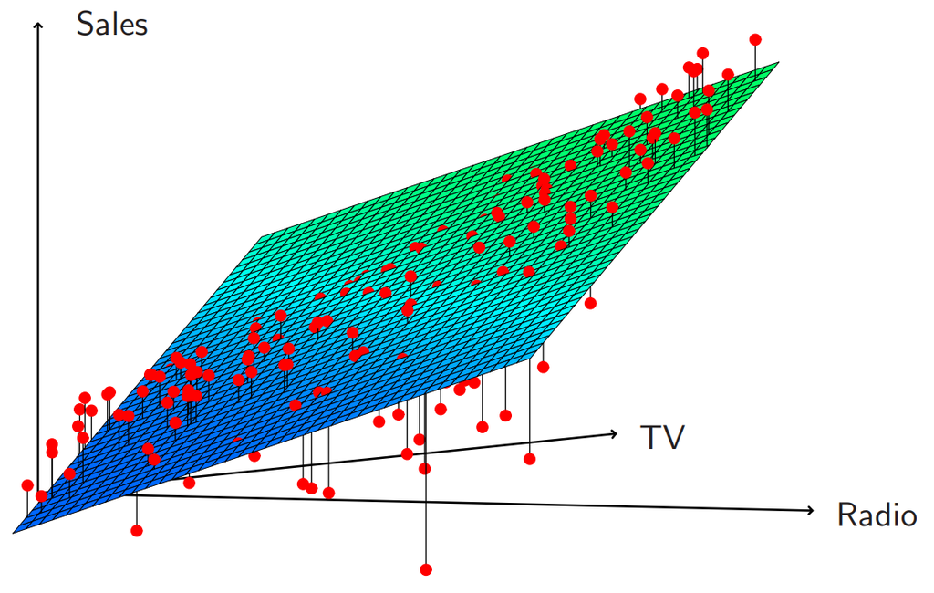

Another way of showing this is by using an interaction plot, which we will show down below after fitting the lm object (if you want to use base R, you don’t need to fit first, but base R graphics look ugly, so we postpone it in order to use a more elegant function from a different package).

Model takes the form

$$\text { sales } =\beta_{0}+\beta_{1} \times \mathrm{TV}+\beta_{2} \times \text { radio }+\beta_{3} \times(\operatorname{radio} \times \mathrm{TV})+\epsilon$$

This can also be represented as either of these *equivalent expressions* below

$$\begin{aligned}
&=\beta_{0}+\left(\beta_{1}+\beta_{3} \times \text { radio }\right) \times \mathrm{TV}+\beta_{2} \times \operatorname{radio}+\epsilon \\
&=\beta_{0}+\beta_{1} \times \mathrm{TV}+\left(\beta_{2}+\beta_{3} \times \text { TV }\right) \times \mathrm{radio}+\epsilon
\end{aligned}$$

You can specify it like this:

```r
lm.ad.TxR = lm(sales ~ TV + radio + newspaper + TV:radio, data = ad)
summary(lm.ad.TxR)
```

```
##
## Call:
## lm(formula = sales ~ TV + radio + newspaper + TV:radio, data = ad)
##
## Residuals:
##     Min      1Q  Median      3Q     Max
## -6.2929 -0.3983  0.1811  0.5957  1.5009
##
## Coefficients:
##              Estimate Std. Error t value Pr(>|t|)
## (Intercept) 6.728e+00  2.533e-01  26.561  < 2e-16 ***
## TV          1.907e-02  1.509e-03  12.633  < 2e-16 ***
## radio       2.799e-02  9.141e-03   3.062  0.00251 **
## newspaper   1.444e-03  3.295e-03   0.438  0.66169
## TV:radio    1.087e-03  5.256e-05  20.686  < 2e-16 ***
## ---
## Signif. codes:  0 '***' 0.001 '**' 0.01 '*' 0.05 '.' 0.1 ' ' 1
##
## Residual standard error: 0.9455 on 195 degrees of freedom
## Multiple R-squared:  0.9678, Adjusted R-squared:  0.9672
## F-statistic:  1466 on 4 and 195 DF,  p-value: < 2.2e-16
```

You can also write `sales ~ (TV + radio)^2 + newspaper` which **does not square the variables** but instead represents all two-way interactions between the two variables.

The interpretation of the coefficient can be according to either of the two equivalent expressions shown above. You can say either

- the coefficient of TV (or alternatively the slope on TV, or you can even say sales per dollar spent on TV advertising) increases by 0.0010873 for every extra dollar spent on radio advertising,
- the coefficient of radio (or alternatively the slope on radio, or you can even say sales per dollar spent on radio advertising) increases by 0.0010873 for every extra dollar spent on TV advertising.

These work out to be equivalent interpretations of the coefficient (again, see equivalent expressions above).

*NOTE:* The interaction estimate is often a much smaller order of magnitude than either coefficient. Just **looking at the magnitude of the coefficient is *NOT* a good way of assessing its significance!** This is because this coefficient is influenced by the scale of the variable (or put it another way, the units it’s measured by!) The **best way to assess significance is to look at the $p$-value** for that estimate!

Now, we can make the interaction plot mentioned above:

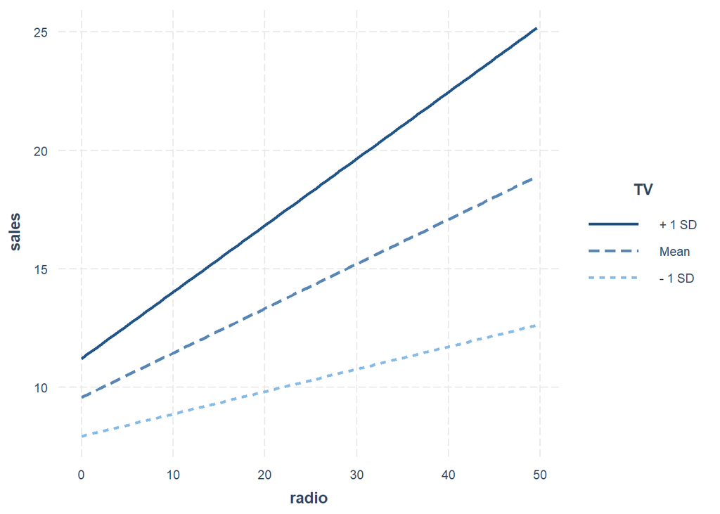

```r
# this function comes from the "interactions" package! make sure you install that!
library(interactions)
interact_plot(lm.ad.TxR, pred=radio, modx=TV)
```

Now you can see the interaction very clearly. If there are **no interactions**, you would expect the lines to **have the same slope**, meaning the efficacy of one variable does NOT vary when another variable changes.

The results in this table suggests that interactions are important. The p-value for the interaction term TV $\times$ radio is extremely low, indicating that there is strong evidence for $H_{A}: \beta_{3} \neq 0$.

The $R^{2}$ for the interaction model is $96.8 \%$, compared to only $89.7 \%$ for the model that predicts sales using TV and radio without an interaction term. This means that $(96.8-89.7) /(100-89.7)=69 \%$ of the variability in sales that remains after fitting the additive model has been explained by the interaction term.

Sometimes it is the case that an interaction term has a very small p-value, but the associated main effects (in this case, TV and radio) do not.

#### The hierarchy principle:

> If we include an interaction in a model, we should also include the main effects, even if the p-values associated with their coefficients are not significant.

The rationale for this principle is that interactions are hard to interpret in a model without main effects—their meaning is changed. Specifically, the interaction terms also contain main effects, if the model has no main effect terms.

This also extends to categorical interactions, and the interpretation is similar. Here’s an example showing showing an interaction plot for the iris dataset, to give you another example of an interaction plot with a clearly present interaction term.

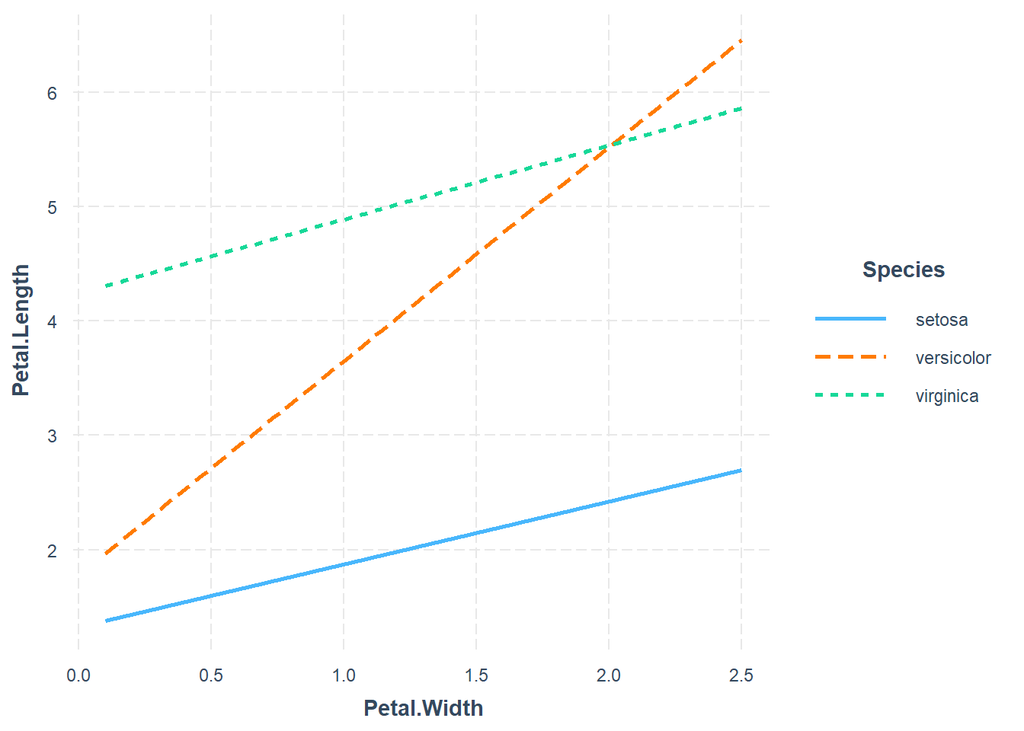

```r
lm(Petal.Length ~ Petal.Width * Species, data=iris) %>%
  interact_plot(pred=Petal.Width, modx=Species)
```

There is clear evidence of an interaction effect (although it only seems to matter if the species is versicolor or not; it looks like setosa and virginica irises have roughly the same relationship between petal length and petal width).

Links to other pages if you want to see some more [examples of interaction plots](https://cran.r-project.org/web/packages/interactions/vignettes/interactions.html) or more [details about the model equation and interpretation](https://www.econometrics-with-r.org/8-3-interactions-between-independent-variables.html).

#### Non-linear terms

This is getting more niche, but sometimes there may be good reason to include additional non-linear terms. You want to *be VERY careful* though! You don’t want to overfit by adding in unnecessary powers when a simple linear term is already good enough!

For example, the `Auto` dataset in the `ISLR` package shows this when you plot miles per gallon vs horsepower:

```r
# remember to install "ISLR" if you don't already have it!
library(ISLR)
head(Auto)
```

```
##   mpg cylinders displacement horsepower weight acceleration year origin
## 1  18         8          307        130   3504         12.0   70      1
## 2  15         8          350        165   3693         11.5   70      1
## 3  18         8          318        150   3436         11.0   70      1
## 4  16         8          304        150   3433         12.0   70      1
## 5  17         8          302        140   3449         10.5   70      1
## 6  15         8          429        198   4341         10.0   70      1
##                        name
## 1 chevrolet chevelle malibu
## 2         buick skylark 320
## 3        plymouth satellite
## 4             amc rebel sst
## 5               ford torino
## 6          ford galaxie 500
```

[figure not shown]

$$\mathrm{mpg}=\beta_{0}+\beta_{1} \times \text { horsepower }+\beta_{2} \times \text { horsepower }{ }^{2}+\epsilon$$

may provide a better fit.